# Assignment 8: Take-Home Final

Factorial Experiments & Response Surface Methodology

SYSEN 5300/6300

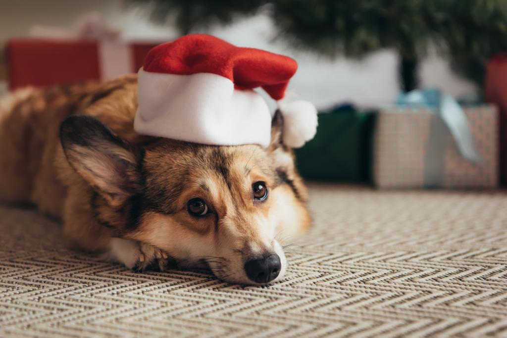

Santa Corgi  
Photo by [Alla Serebrina](https://create.vista.com/unlimited/stock-photos/212581280/stock-photo-cute-welsh-corgi-dog-santa/)

# Prompt

## Instructions

For each question in this assignment, show the steps of your calculation in `R`. (Please only use `R` to check your results.)

- Please work on it in a team of up to 6 members.
- This assignment will be graded out of 100 points, where 100 / 100 = 100%.
- Teams may talk to each other about how to approach the problems, but *we expect each team to do their own work.*
- Please submit a `.docx` file listing your `R` code and responses, according to [**this format**](https://docs.google.com/document/d/1KXyoBa4Y4mYZkVJZnZM4u8sMjK_1bY9vewdN68poo8w/edit?usp=sharing). All lines of code must be clearly explained.
- All analyses must be performed in `R`.
- I highly recommend collaborating in Google Docs, but you must submit a `.docx` file at the end. (Google Doc share links will *not* be accepted.)
- *(All values below are hypothetical, unless otherwise indicated, for educational purposes, but are meant to be plausible examples.)*

**Be sure to review the Background and Measures tabs above before starting!**

## Background

**Jolly Cobblers**, a family-owned North Pole shoe store, has been selling quality shoes to Santa and his elves for generations. Unfortunately, rising market competition has forced **Jolly Cobblers** to re-evaluate their product design, because after a night delivering presents, Santa’s boots face a *lot* of wear and tear; the backstay of the heel always breaks by the end of the night. Their customers need a sturdier boot, ASAP - otherwise Santa will just buy boots on Amazon instead.

So, the elves at **Jolly Cobblers** designed and implemented a factorial experiment to develop a more durable boot!

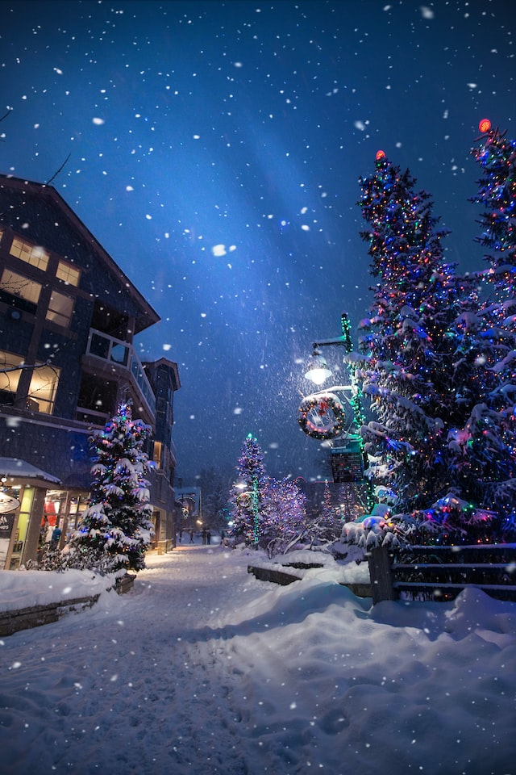

## Measures

They measured the following outcome:

- **boot durability**: the **number of times an elf can hammer a boot heel** with the weight of Santa Claus before the heel breaks.

**For example, click here to see this **Heel Stomper**!**

[video not shown]

Then, they made a series of `240` boots, randomly assigning groups of `15` boots to a particular amount of `leather`, `layers`, `foam` thickness, and waterproofing `solvent` concentration. All other aspects of the production process were held constant.

- **leather**: thickness of the leather, in **millimeters** (`1.0` vs. `1.5` millimeters).
- **layers**: layers of leather (`2` vs. `3`)
- **foam**: thickness of foam padding on the backstay (`3.0` vs. `4.0` millimeters).
- **solvent**: concentration of a water-proofing solvent (`0.25` = 25% solvent with 75% water; `0.50` = equal parts solvent and water).

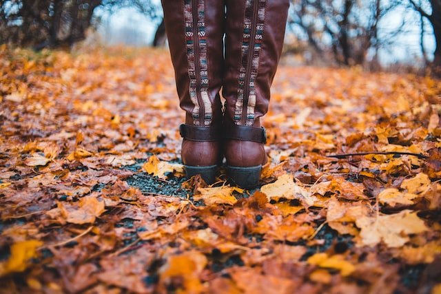

Santa needs some new boots!  
Photo by [Erik Mclean on Unsplash](https://unsplash.com/photos/4Q0QynPM8UA)

# Data & Packages

[output not shown]

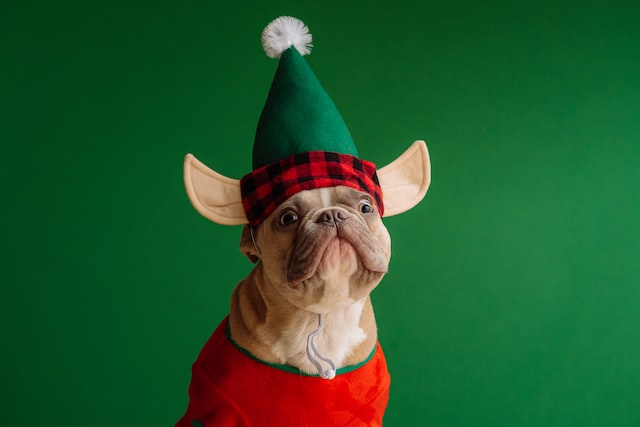

Staff at Jolly Cobblers are eager to use Six Sigma!  
Photo by [Karsten Winegeart on Unsplash](https://unsplash.com/s/photos/santa?utm_source=unsplash&utm_medium=referral&utm_content=creditCopyText)

```r
# Load packages
library(tidyverse)
library(broom)
library(viridis)
library(metR)

# Questions 1-2 uses this dataset, 'boots.csv'
boots = read_csv("/cloud/project/workshops/boots.csv")
# Questions 3-4 uses this dataset, 'allboots.csv"
allboots = read_csv("/cloud/project/workshops/allboots.csv")

# Let's view the boots dataset
boots %>% glimpse()
```

# Q1. Factorial Design at 2 Levels (20 points)

Using the `boots.csv` dataset, create a **table of contrasts** estimating the **direct/main effects** and **interaction effects** (15 effects total). Use the **difference of means in R** (not a regression model).

- This table should contain 15 rows and 5 columns, with columns for the (1) `contrast`, (2) estimated `effect`, (3) standard error (`se`), and (4) `lower` and (5) `upper` confidence intervals. Follow the instructions below to create this table, showing your work in `R`.
1. (**5 points**) Estimate the **standard error** for this factorial experiment’s differences of means.
2. (**5 points**) Estimate the **direct/main effects** of each treatment (4 total).
3. (**5 points**) Estimate all **interaction effects** of every possible unique combination of treatments (11 total).
4. (**5 points**) Use the data from parts *a*, *b*, and *c* to estimate **upper and lower confidence intervals** for each effect from parts *b* & *c*, with a 95% confidence level. Report the finished table, presenting results rounded to *1 decimal place*.
- *Hint*: `bind_cols()` may help you combine `data.frames`.

# Q2. Factorial Experiment Quantities of Interest (20 points)

1. (**5 points**) Using *only* the information gathered in **Q1 part d**, how would you determine which of the estimated effects are likely to be *real, significant* effects and not just due to sampling error?
2. (**10 points**) Which of the estimated effects are likely to be the real effects and not just due to chance? Describe each *significant* effects in a sentence or more, listing (1) the contrast levels in their original units, (2) the estimated effect in units of *times the boot heel is crushed*, and (3) the confidence interval.
3. (**5 points**) The present conditions of operation are the lower settings for each contrast (`thickness` = 1 mm, `layers` = 2, `foam` = 3, & `solvent` = 0.25). Some of these potential changes cost more than others! Use the information below to deduce *which* of your significant effects is *most cost effective*.

For each boot, it costs…

- $5 dollars to improve the thickness of the leather from 1 mm to 1.5mm,
- $2 to increase the layers from 2 to 3,
- $1 to increase the foam padding from 3 mm to 4 mm, and…
- $2.5 to increase the concentration of waterproofing solvent from 25% to 50%.
- *Hint*: Use the costs above to calculate the **added-cost** of each treatment effect (eg. the cost of switching solvent from 25% to 50% AND layers from 2 to 3 would be `$2 + $2.50 = $4.50`). Then, use your `estimate` to calculate the added-durability of a boot in **times crushed per dollar spent**! (Round your payoff to 1 decimal place.)

# Q3. Interaction Models & RSM (25 points)

Enthused by their promising findings, the elves added a few more contrast levels to their existing treatment variables (`thickness` = 1, 1.5, & 2 mm, `layers` = 2, 3, & 4, `foam` = 3, 3.5, 4, and solvent = `0.25`, `0.375`, & `0.5`). Their data is available is `allboots.csv` (it’s very high tech at the North Pole).

```r
# Import data for Questions 3-4
allboots = read_csv("/cloud/project/workshops/allboots.csv")

# View it!
allboots %>% glimpse()
```

```
## Rows: 1,215
## Columns: 7
## $ id         <dbl> 1, 2, 3, 4, 5, 6, 7, 8, 9, 10, 11, 12, 13, 14, 15, 16, 17, 18, 19, 20,…
## $ group      <dbl> 1, 1, 1, 1, 1, 1, 1, 1, 1, 1, 1, 1, 1, 1, 1, 2, 2, 2, 2, 2, 2, 2, 2, 2…
## $ durability <dbl> 44, 123, 52, 62, 65, 82, 93, 14, 69, 121, 43, 65, 14, 69, 82, 152, 131…
## $ thickness  <dbl> 1, 1, 1, 1, 1, 1, 1, 1, 1, 1, 1, 1, 1, 1, 1, 1, 1, 1, 1, 1, 1, 1, 1, 1…
## $ layers     <dbl> 2, 2, 2, 2, 2, 2, 2, 2, 2, 2, 2, 2, 2, 2, 2, 2, 2, 2, 2, 2, 2, 2, 2, 2…
## $ foam       <dbl> 3, 3, 3, 3, 3, 3, 3, 3, 3, 3, 3, 3, 3, 3, 3, 3, 3, 3, 3, 3, 3, 3, 3, 3…
## $ solvent    <dbl> 0.250, 0.250, 0.250, 0.250, 0.250, 0.250, 0.250, 0.250, 0.250, 0.250, …
```

1. (**10 points**) Estimate `durability` using a second-order polynomial model in `lm()` with **all** interaction effects, called `m1`. Write out your entire model equation. (You may round coefficients to the first decimal place.)
2. (**5 points**) Your outcome is a count bounded at zero. Make 2 more models `m2` and `m3`, one of which models the square root of your outcome and one of which models the natural log of your outcome. Which of your 3 models fits best? How do you know? Report the $R^{2}$, F statistic, and p-value for each model. (Round your your answers to 3 decimal places.)
3. (**10 points**) Using the best fitting model you selected in *part b*, generate a grid of predictions using the specs below. Visualize that grid as a contour plot with labels in `ggplot!` (Do not use `contour()`.)
- Vary the `thickness` from `1` to `4` by `0.1` mm each and number of `layers` from `1` to `4` by `1` layer each!
- Hold the level of `foam` at their real current values of `3 mm` and `solvent` at `25%`. (Be sure to back-transform your predictions **if** your outcome is transformed.)
- Add clear labels, themes, and a **visually appealing** color palette (not the default blue).

# Q4. RSM Quantities of Interest (35 points)

The elves are excited about their promising results, but they really need to refine them into usable quantities of interest for decision-making. Answer the questions below to help them analyze their results.

```r
# Import data for Questions 3-4
allboots = read_csv("/cloud/project/workshops/allboots.csv")

# View it!
allboots %>% glimpse()
```

```
## Rows: 1,215
## Columns: 7
## $ id         <dbl> 1, 2, 3, 4, 5, 6, 7, 8, 9, 10, 11, 12, 13, 14, 15, 16, 17, 18, 19, 20,…
## $ group      <dbl> 1, 1, 1, 1, 1, 1, 1, 1, 1, 1, 1, 1, 1, 1, 1, 2, 2, 2, 2, 2, 2, 2, 2, 2…
## $ durability <dbl> 44, 123, 52, 62, 65, 82, 93, 14, 69, 121, 43, 65, 14, 69, 82, 152, 131…
## $ thickness  <dbl> 1, 1, 1, 1, 1, 1, 1, 1, 1, 1, 1, 1, 1, 1, 1, 1, 1, 1, 1, 1, 1, 1, 1, 1…
## $ layers     <dbl> 2, 2, 2, 2, 2, 2, 2, 2, 2, 2, 2, 2, 2, 2, 2, 2, 2, 2, 2, 2, 2, 2, 2, 2…
## $ foam       <dbl> 3, 3, 3, 3, 3, 3, 3, 3, 3, 3, 3, 3, 3, 3, 3, 3, 3, 3, 3, 3, 3, 3, 3, 3…
## $ solvent    <dbl> 0.250, 0.250, 0.250, 0.250, 0.250, 0.250, 0.250, 0.250, 0.250, 0.250, …
```

1. (**5 points**) Based on your grid from **Q3 part c**, without changing anything else, what precise `thickness` and total `layers` produces the optimal predicted `durability`?
- *Hint*: This is just `dplyr` data-wrangling. Use your `data.frame` to find precise numbers.
2. (**10 points**) Calculate the *predicted* `durability` with a 95% confidence interval, under (1) optimal conditions (from **Q4 part a**) vs. (2) under current conditions. Current traits are: thickness = 1, layers = 2, foam = 3, and solvent = 0.25. (Remember to back-transform your outcome variable **if** necessary.)
3. (**5 points**) Visualize your two confidence intervals for the original vs. optimal `durability` from **Q4b** in a single plot in `ggplot`! (Be sure to use clear labeling, themes, and colors.)
4. (**10 points**) Suppose you want to cut costs for the *other* factors. Create a new grid, repeating the **same conditions** but allowing the level of foam padding to **vary** between `2`, `2.5`, and `3` mm. Visualize the new plot, *split into panels* for each level of `foam`! Each bin should have a width of `500`.
5. (**5 points**) For each level of foam, `filter()` to find the optimal `durability` and the associated level of `thickness` and `layers`. If you decrease the amount of `foam` padding, what do you need to do to the `thickness` and/or `layers` to achieve optimal `durability`?
- *Hint*: This is just data-wrangling. Use your `dplyr` toolkit.

# End

You made it! Submit your results and code to canvas, and then take a well deserved break!

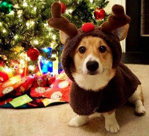

Rudolph the Red-Nose Corgi says Congrats!  
Courtesy of the World-Wide Web